# Tugas 1 — Pengantar Analisis Data Kategori

Latihan Analisis Data dengan R dan Quarto

Mahasiswa

Ridho Fatilla Wibawa

NIM

241061010

Kode Tugas

ADK1-0701822E

**Tujuan tugas.** Gunakan kembali konsep dan fungsi R yang telah dibahas pada Pertemuan 1 untuk mengenali struktur data kategori, membuat ringkasan deskriptif, memvisualisasikan data, dan menjelaskan insight secara hati-hati.

**CatatanPola kerja**

Ikuti pola kelas: **predict → run → inspect → explain**.

Pada setiap bagian diberikan **sedikit petunjuk kode**.  
Jika diminta menjelaskan atau menuliskan interpretasi, gunakan kotak **Jawaban Anda** yang telah disediakan.

# 1 1. Mengenali Data

Gunakan R untuk melihat beberapa baris awal, struktur data, dan nama variabel.

**TipPetunjuk kode**

```r
head(...)
str(...)
names(...)
```

Ganti `...` dengan objek data yang digunakan.

```r
head(data)
```

```
  RecordID     ProgramStudi Gender DeviceUtama ModaBelajar    Kepuasan
1   673444       Matematika      L  Smartphone       Video       Cukup
2   955822   Sains Aktuaria      L      Tablet       Video Sangat Puas
3   878446 Sistem Informasi      P      Laptop     Diskusi  Tidak Puas
4   324098   Sains Aktuaria      L      Tablet       Video        Puas
5   137363   Sains Aktuaria      P      Laptop       Video        Puas
6   915265   Sains Aktuaria      L  Smartphone     Diskusi  Tidak Puas
  IntensitasBelajar DurasiBelajarJam       PaketID
1            Sedang              4.6 ADK1-0701822E
2            Tinggi              5.9 ADK1-0701822E
3            Rendah              2.7 ADK1-0701822E
4            Tinggi             10.2 ADK1-0701822E
5            Sedang             10.4 ADK1-0701822E
6            Tinggi              7.7 ADK1-0701822E
```

```r
str(data)
```

```
'data.frame':   93 obs. of  9 variables:
 $ RecordID         : int  673444 955822 878446 324098 137363 915265 368269 474351 939088 497705 ...
 $ ProgramStudi     : chr  "Matematika" "Sains Aktuaria" "Sistem Informasi" "Sains Aktuaria" ...
 $ Gender           : chr  "L" "L" "P" "L" ...
 $ DeviceUtama      : chr  "Smartphone" "Tablet" "Laptop" "Tablet" ...
 $ ModaBelajar      : chr  "Video" "Video" "Diskusi" "Video" ...
 $ Kepuasan         : chr  "Cukup" "Sangat Puas" "Tidak Puas" "Puas" ...
 $ IntensitasBelajar: chr  "Sedang" "Tinggi" "Rendah" "Tinggi" ...
 $ DurasiBelajarJam : num  4.6 5.9 2.7 10.2 10.4 7.7 5.3 5.1 8.7 3.2 ...
 $ PaketID          : chr  "ADK1-0701822E" "ADK1-0701822E" "ADK1-0701822E" "ADK1-0701822E" ...
```

```r
names(data)
```

```
[1] "RecordID"          "ProgramStudi"      "Gender"
[4] "DeviceUtama"       "ModaBelajar"       "Kepuasan"
[7] "IntensitasBelajar" "DurasiBelajarJam"  "PaketID"
```

Lengkapi tabel berikut.

| Variabel | Jenis Variabel | Alasan Singkat |
| --- | --- | --- |
| RecordID | Identifier | Penanda unik setiap record |
| ProgramStudi | Nominal | Kategori tanpa urutan |
| Gender | Nominal | Kategori tanpa urutan |
| DeviceUtama | Nominal | Kategori tanpa urutan |
| ModaBelajar | Nominal | Kategori tanpa urutan |
| Kepuasan | Ordinal | Kategori urutan tingkat kepuasan |
| IntensitasBelajar | Ordinal | Kategori urutan tingkat intensitas |
| DurasiBelajarJam | Numerik | Berupa nilai angka yang dapat diukur |

Jawab singkat:

1. Variabel mana yang merupakan identifier?
2. Variabel mana yang bersifat ordinal?
3. Mengapa kode angka belum tentu berarti data numerik?

**Jawaban Anda**

1. RecordID, karena digunakan sebagai penanda unik setiap record.
2. Kepuasan dan IntensitasBelajar, karena kedua variabel tersebut memiliki urutan kategori.
3. Karena angka dapat digunakan sebagai kode atau label kategori, sehingga angka tersebut tidak selalu menunjukkan nilai numerik yang dapat dihitung.

# 2 2. Menyiapkan Data Kategori

Variabel latihan Anda:

```r
cat("Nominal :", identitas$nominal_utama[1], "\n")
```

```
Nominal : ModaBelajar
```

```r
cat("Ordinal :", identitas$ordinal_utama[1], "\n")
```

```
Ordinal : Kepuasan
```

```r
cat("Urutan  :", identitas$urutan_ordinal[1], "\n")
```

```
Urutan  : Tidak Puas|Cukup|Puas|Sangat Puas
```

Lakukan hal berikut:

1. ubah variabel nominal menjadi factor;
2. ubah variabel ordinal menjadi ordered factor;
3. periksa level kategorinya.

**TipPetunjuk kode**

Untuk nominal:

```r
factor(...)
levels(...)
```

Untuk ordinal:

```r
factor(..., levels = ..., ordered = TRUE)
```

```r
nominal_var <- identitas$nominal_utama[1]
ordinal_var <- identitas$ordinal_utama[1]
urutan <- strsplit(identitas$urutan_ordinal[1], "\\|")[[1]]

# Tulis kode Anda di bawah ini
data[[nominal_var]] <- factor(data[[nominal_var]])

data[[ordinal_var]] <- factor(
  data[[ordinal_var]],
  levels = urutan,
  ordered = TRUE
)

levels(data[[nominal_var]])
```

```
[1] "Buku"    "Diskusi" "Praktik" "Video"
```

```r
levels(data[[ordinal_var]])
```

```
[1] "Tidak Puas"  "Cukup"       "Puas"        "Sangat Puas"
```

Tuliskan satu kalimat: **mengapa urutan level ordinal perlu ditetapkan dengan benar?**

**Jawaban Anda**

Urutan level ordinal perlu ditetapkan dengan benar agar R mengenali tingkatan kategori sesuai makna datanya.

# 3 3. Quality Control Awal

Lakukan pemeriksaan sederhana terhadap:

- struktur data;
- level/kategori;
- missing value;
- konsistensi penulisan kategori.

**TipPetunjuk kode**

Beberapa pola fungsi yang dapat digunakan:

```r
str(...)
levels(...)
unique(...)
is.na(...)
colSums(...)
```

Pilih fungsi yang sesuai dengan tujuan pemeriksaan Anda.

```r
str(data)
```

```
'data.frame':   93 obs. of  9 variables:
 $ RecordID         : int  673444 955822 878446 324098 137363 915265 368269 474351 939088 497705 ...
 $ ProgramStudi     : chr  "Matematika" "Sains Aktuaria" "Sistem Informasi" "Sains Aktuaria" ...
 $ Gender           : chr  "L" "L" "P" "L" ...
 $ DeviceUtama      : chr  "Smartphone" "Tablet" "Laptop" "Tablet" ...
 $ ModaBelajar      : Factor w/ 4 levels "Buku","Diskusi",..: 4 4 2 4 4 2 2 4 2 4 ...
 $ Kepuasan         : Ord.factor w/ 4 levels "Tidak Puas"<"Cukup"<..: 2 4 1 3 3 1 1 1 4 1 ...
 $ IntensitasBelajar: chr  "Sedang" "Tinggi" "Rendah" "Tinggi" ...
 $ DurasiBelajarJam : num  4.6 5.9 2.7 10.2 10.4 7.7 5.3 5.1 8.7 3.2 ...
 $ PaketID          : chr  "ADK1-0701822E" "ADK1-0701822E" "ADK1-0701822E" "ADK1-0701822E" ...
```

```r
levels(data[[nominal_var]])
```

```
[1] "Buku"    "Diskusi" "Praktik" "Video"
```

```r
levels(data[[ordinal_var]])
```

```
[1] "Tidak Puas"  "Cukup"       "Puas"        "Sangat Puas"
```

```r
unique(data$Gender)
```

```
[1] "L" "P"
```

```r
unique(data$ModaBelajar)
```

```
[1] Video   Diskusi Buku    Praktik
Levels: Buku Diskusi Praktik Video
```

```r
unique(data$Kepuasan)
```

```
[1] Cukup       Sangat Puas Tidak Puas  Puas        <NA>
Levels: Tidak Puas < Cukup < Puas < Sangat Puas
```

```r
unique(data$IntensitasBelajar)
```

```
[1] "Sedang" "Tinggi" "Rendah" NA
```

```r
colSums(is.na(data))
```

```
         RecordID      ProgramStudi            Gender       DeviceUtama
                0                 0                 0                 0
      ModaBelajar          Kepuasan IntensitasBelajar  DurasiBelajarJam
                0                 1                 2                 1
          PaketID
                0
```

Tuliskan **dua temuan singkat** dari pemeriksaan tersebut.

**Jawaban Anda**

1. Terdapat missing value pada variabel Kepuasan sebanyak 1 data, IntensitasBelajar sebanyak 2 data, dan DurasiBelajarJam sebanyak 1 data.
2. ModaBelajar memiliki 4 kategori, yaitu Buku, Diskusi, Praktik, dan Video. Kepuasan memiliki 4 kategori dengan urutan Tidak Puas, Cukup, Puas, dan Sangat Puas. Terdapat missing value pada Kepuasan dan IntensitasBelajar.

# 4 4. Frekuensi dan Proporsi

Sebelum menjalankan kode, prediksi:

> Menurut Anda, kategori mana yang paling banyak muncul pada variabel nominal Anda?

**Prediksi Anda**

Menurut saya, kategori ModaBelajar yang mungkin paling banyak muncul adalah video.

Setelah itu, buat:

- tabel frekuensi untuk variabel nominal;
- proporsi untuk variabel ordinal.

**TipPetunjuk kode**

```r
table(...)
prop.table(...)
```

Anda dapat menyimpan hasil `table()` ke sebuah objek terlebih dahulu sebelum menghitung proporsi.

```r
freq_nominal <- table(data[[nominal_var]])
freq_ordinal <- table(data[[ordinal_var]])

freq_nominal
```

```
   Buku Diskusi Praktik   Video
     14      29      10      40
```

```r
prop.table(freq_ordinal)
```

```
 Tidak Puas       Cukup        Puas Sangat Puas
  0.1847826   0.3586957   0.2391304   0.2173913
```

Tuliskan **dua kalimat insight** berdasarkan output.

**Interpretasi Anda**

1. Pada variabel ModaBelajar, kategori Video memiliki frekuensi tertinggi, yaitu 40 mahasiswa, sedangkan Praktik memiliki frekuensi terendah, yaitu 10 mahasiswa.
2. Pada variabel Kepuasan, kategori Cukup memiliki proporsi terbesar sebesar 35,87%, sedangkan Tidak Puas memiliki proporsi sebesar 18,48% dari 92 data yang valid.

# 5 5. Tabel Silang

Pasangan variabel Anda:

```r
x <- identitas$tab_baris[1]
y <- identitas$tab_kolom[1]

cat("Baris :", x, "\n")
```

```
Baris : Gender
```

```r
cat("Kolom :", y, "\n")
```

```
Kolom : Kepuasan
```

Buat tabel silang untuk kedua variabel tersebut.

Jika diperlukan, tampilkan proporsi per baris untuk membantu membaca pola.

**TipPetunjuk kode**

```r
table(..., ...)
prop.table(..., margin = 1)
```

Lengkapi sendiri objek yang diperlukan.

```r
tab_silang <- table(data$Gender, data$Kepuasan)

tab_silang
```

```
    Tidak Puas Cukup Puas Sangat Puas
  L         12    14   13          10
  P          5    19    9          10
```

```r
prop.table(tab_silang, margin = 1)
```

```
    Tidak Puas     Cukup      Puas Sangat Puas
  L  0.2448980 0.2857143 0.2653061   0.2040816
  P  0.1162791 0.4418605 0.2093023   0.2325581
```

Tuliskan **satu kalimat** yang menjelaskan pola yang tampak.

Pada data ini, proporsi responden dengan kepuasan “Cukup” lebih tinggi pada gender P (44,19%) dibandingkan gender L (28,57%). …

**Penting**

Gunakan bahasa deskriptif. Jangan langsung menyimpulkan adanya hubungan signifikan atau sebab-akibat.

# 6 6. Visualisasi Kategorik

Variabel yang divisualisasikan:

```r
v <- identitas$visualisasi[1]
cat("Variabel grafik :", v, "\n")
```

```
Variabel grafik : Kepuasan
```

Buat **satu grafik batang** seperti yang telah dipelajari pada Pertemuan 1.

**TipPetunjuk kode**

```r
library(ggplot2)

ggplot(..., aes(x = ...)) +
  geom_bar() +
  labs(...)
```

Sesuaikan objek data, variabel, judul, dan label sumbu.

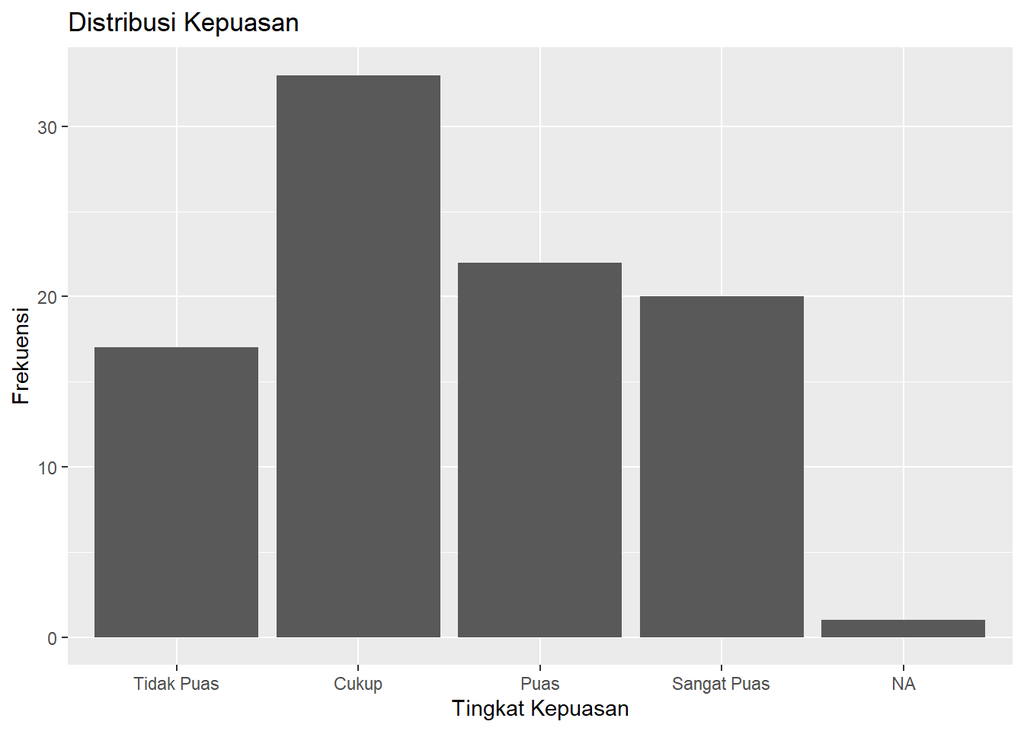

```r
library(ggplot2)

ggplot(data, aes(x = Kepuasan)) +
  geom_bar() +
  labs(
    title = "Distribusi Kepuasan",
    x = "Tingkat Kepuasan",
    y = "Frekuensi"
  )
```

Tuliskan **satu kalimat** interpretasi grafik.

Grafik menunjukkan bahwa kategori Cukup memiliki frekuensi tertinggi, sedangkan kategori Tidak Puas, Puas, dan Sangat Puas memiliki frekuensi yang lebih rendah. Terdapat 1 data dengan nilai NA pada variabel Kepuasan.

# 7 7. Kesimpulan

Tuliskan **3 poin kesimpulan singkat** berdasarkan hasil analisis.

Setiap kesimpulan harus:

- didukung oleh output yang telah Anda hasilkan;
- menggunakan angka yang relevan;
- ditulis dengan bahasa Anda sendiri;
- tidak menggunakan klaim sebab-akibat.

**Kesimpulan Anda**

1. Variabel ModaBelajar merupakan data kategorik nominal dengan 4 kategori, dan kategori Video memiliki frekuensi tertinggi yaitu 40 dari 93 data.
2. Pada variabel Kepuasan, kategori Cukup memiliki proporsi terbesar yaitu 35,87% dari 92 data yang valid, dengan 1 data missing.
3. Berdasarkan tabel silang Gender dan Kepuasan, proporsi kategori Cukup pada gender P sebesar 44,19%, sedangkan pada gender L sebesar 28,57%.

**Analisis Data Kategori — Tugas 1**  
Predict → Run → Inspect → Explain